# Evaluación de Políticas Públicas utilizando herramientas de Machine Learning

Tomás Sawaya

## Introducción

En el presente documento, intentaremos evaluar mediante herramientas de Machine Learning posibles métodos para la evaluación y posterior toma de decisión sobre respectivas políticas públicas que deban llevarse a cabo.

Intentaremos plasmar un modelo de clusterización entre provincias para poder encontrar una correlación (significativa) entre ellas y poder agrupar los paquetes de políticas específicos para cada subconjunto.

Cabe destacar que la base utilizada corresponde al Censo 2010 provisto por el Instituto Nacional de Estadística y Censos - INDEC Argentina, ya que no se cuenta con información detallada y actualizada al año 2021 debido a la pandemia COVID-19.

Sin más preámbulos, nos abocaremos al análisis detallado del modelo:

# Inspección y Visualización primaria de datos

Comenzaremos inspeccionando las principales variables de la base de datos, luego elaboraremos distintos rankings que nos permitan discernir las principales diferencias o similitudes entre las provincias para luego seguir adelante con el proceso de clusterización.

| province | gdp | illiteracy | poverty | deficient_infra | school_dropout | no_healthcare | birth_mortal | pop | movie_theatres_per_cap | doctors_per_cap |
| --- | --- | --- | --- | --- | --- | --- | --- | --- | --- | --- |
| Buenos Aires | 292689868 | 1.383240 | 8.167798 | 5.511856 | 0.7661682 | 48.7947 | 4.4 | 15625084 | 6.00e-06 | 0.0048356 |
| Catamarca | 6150949 | 2.344140 | 9.234095 | 10.464484 | 0.9519631 | 45.0456 | 1.5 | 367828 | 5.40e-06 | 0.0045021 |
| Córdoba | 69363739 | 2.714140 | 5.382380 | 10.436086 | 1.0350558 | 45.7640 | 4.8 | 3308876 | 1.12e-05 | 0.0101754 |
| Corrientes | 7968013 | 5.602420 | 12.747191 | 17.438858 | 3.8642652 | 62.1103 | 5.9 | 992595 | 4.00e-06 | 0.0044953 |
| Chaco | 9832643 | 7.517580 | 15.862619 | 31.479527 | 2.5774621 | 65.5104 | 7.5 | 1055259 | 2.80e-06 | 0.0036048 |
| Chubut | 17747854 | 1.548060 | 8.051752 | 8.044618 | 0.5863094 | 39.5473 | 3.0 | 509108 | 1.57e-05 | 0.0044981 |
| Entre Ríos | 20743409 | 3.185580 | 7.288751 | 18.794568 | 1.8871881 | 48.6571 | 3.1 | 1235994 | 5.70e-06 | 0.0046788 |
| Formosa | 3807057 | 4.610640 | 17.035583 | 28.004984 | 2.2689741 | 65.8126 | 16.2 | 530162 | 3.80e-06 | 0.0034405 |
| Jujuy | 6484938 | 2.151390 | 13.367965 | 12.483179 | 0.7212945 | 54.1615 | 3.7 | 673307 | 3.00e-06 | 0.0039581 |
| La Pampa | 6990262 | 1.539300 | 3.398774 | 16.505714 | 0.2040934 | 45.4764 | 7.2 | 318951 | 1.88e-05 | 0.0054146 |
| La Rioja | 5590516 | 2.773210 | 10.875152 | 7.403254 | 3.8449494 | 40.8341 | 11.4 | 333642 | 1.20e-05 | 0.0050923 |
| Mendoza | 33431369 | 2.200200 | 5.692798 | 3.839852 | 1.0637179 | 50.5843 | 4.4 | 1738929 | 8.10e-06 | 0.0057202 |
| Misiones | 9646826 | 6.863950 | 13.529788 | 8.325740 | 3.1291244 | 57.8339 | 8.1 | 1101593 | 1.80e-06 | 0.0028804 |
| Neuquén | 22564106 | 1.943750 | 9.456635 | 11.267278 | 1.3935038 | 48.7431 | 3.3 | 551266 | 9.10e-06 | 0.0050665 |
| Río Negro | 10264584 | 2.031420 | 8.678391 | 14.885444 | 0.4080420 | 49.9463 | 0.8 | 638645 | 9.40e-06 | 0.0048979 |
| Salta | 13438835 | 3.346090 | 16.870500 | 14.182303 | 1.4820300 | 60.4230 | 5.8 | 1214441 | 4.10e-06 | 0.0039911 |
| San Juan | 8262309 | 2.963260 | 9.050784 | 3.914390 | 3.2984129 | 52.9684 | 4.2 | 681055 | 5.90e-06 | 0.0050436 |
| San Luis | 11780849 | 3.433650 | 6.593771 | 9.679894 | 2.0001724 | 51.6154 | 3.8 | 432310 | 4.60e-06 | 0.0061021 |
| Santa Cruz | 11663738 | 0.791485 | 8.024762 | 7.411364 | 0.2892622 | 29.2321 | 3.3 | 273964 | 1.10e-05 | 0.0042706 |
| Santa Fe | 81588690 | 1.975940 | 6.081012 | 11.869195 | 2.8721807 | 41.9660 | 2.6 | 3194537 | 6.60e-06 | 0.0066717 |
| Santiago del Estero | 8387859 | 6.272090 | 11.759000 | 20.491433 | 2.3255981 | 63.6637 | 1.7 | 874006 | 3.40e-06 | 0.0028215 |
| Tucumán | 13856199 | 3.770370 | 11.214239 | 6.466665 | 0.9772847 | 48.2242 | 3.0 | 1448188 | 4.80e-06 | 0.0055007 |

### Analizamos sus variables principales:

|  | gdp | illiteracy | poverty | deficient_infra | school_dropout | no_healthcare | birth_mortal | pop | movie_theatres_per_cap | doctors_per_cap |
| --- | --- | --- | --- | --- | --- | --- | --- | --- | --- | --- |
|  | Min. : 3807057 | Min. :0.7915 | Min. : 3.399 | Min. : 3.84 | Min. :0.2041 | Min. :29.23 | Min. : 0.800 | Min. : 273964 | Min. :1.816e-06 | Min. :0.002821 |
|  | 1st Qu.: 8041587 | 1st Qu.:1.9898 | 1st Qu.: 7.473 | 1st Qu.: 7.57 | 1st Qu.:0.8126 | 1st Qu.:45.55 | 1st Qu.: 3.025 | 1st Qu.: 514372 | 1st Qu.:4.052e-06 | 1st Qu.:0.004061 |
|  | Median : 10964161 | Median :2.7437 | Median : 9.142 | Median :10.87 | Median :1.4378 | Median :49.37 | Median : 4.000 | Median : 777530 | Median :5.768e-06 | Median :0.004757 |
|  | Mean : 30557028 | Mean :3.2255 | Mean : 9.926 | Mean :12.68 | Mean :1.7249 | Mean :50.77 | Mean : 4.986 | Mean : 1686352 | Mean :7.144e-06 | Mean :0.004894 |
|  | 3rd Qu.: 19994520 | 3rd Qu.:3.6862 | 3rd Qu.:12.500 | 3rd Qu.:16.10 | 3rd Qu.:2.5145 | 3rd Qu.:56.92 | 3rd Qu.: 5.875 | 3rd Qu.: 1230606 | 3rd Qu.:9.314e-06 | 3rd Qu.:0.005334 |
|  | Max. :292689868 | Max. :7.5176 | Max. :17.036 | Max. :31.48 | Max. :3.8643 | Max. :65.81 | Max. :16.200 | Max. :15625084 | Max. :1.881e-05 | Max. :0.010175 |

Como se puede apreciar, en la matriz anteriorse detallan todas las estadísticas de relevancia para la presente base de datos.

Para cada variable se explicita su correspondiente valor mínimo y máximo, su media y su mediana y cuartiles.

### Rankings de Provincias

Lo que haremos ahora será evaluar mediante rankings, las variables PBI per Cápita, Pobreza y Población para tener una noción más objetiva de a qué nos estamos enfrentando y cuales son las principales diferencias de las provincias.

#### Top 10 provincias más ricas:

```
##        province gdp_per_cap
## 1    Santa Cruz    42.57398
## 2       Neuquén    40.93143
## 3        Chubut    34.86069
## 4      San Luis    27.25093
## 5      Santa Fe    25.54007
## 6      La Pampa    21.91641
## 7       Córdoba    20.96293
## 8       Mendoza    19.22526
## 9  Buenos Aires    18.73205
## 10   Entre Ríos    16.78277
```

La provincia que lidera el ranking de PBI per Cápita es la provincia de Santa Cruz, seguida de Neuquén y Chubut en el Top 3.

**Si lo graficamos:**

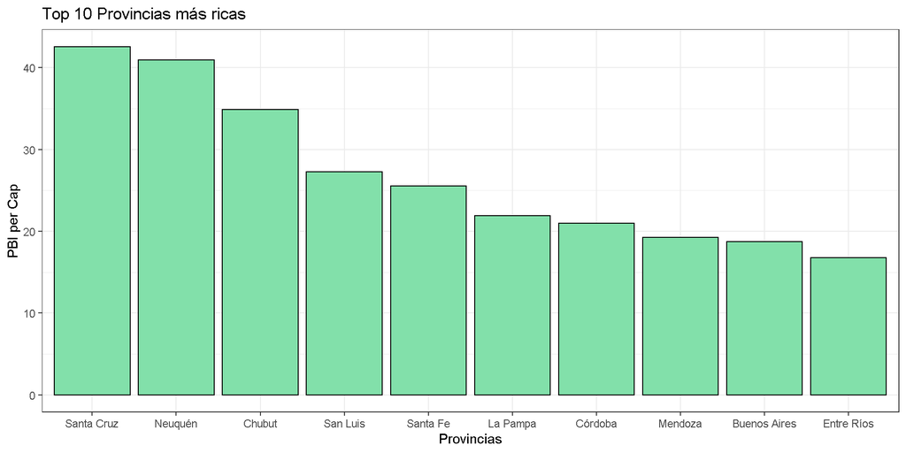

[output not shown]

#### Top 10 provincias más pobres:

Ahora hacia el otro lado del espectro, nos encontramos con el Top 10 de provincias más pobres.

```
##               province   poverty
## 1              Formosa 17.035583
## 2                Salta 16.870500
## 3                Chaco 15.862619
## 4             Misiones 13.529788
## 5                Jujuy 13.367965
## 6           Corrientes 12.747191
## 7  Santiago del Estero 11.759000
## 8              Tucumán 11.214239
## 9             La Rioja 10.875152
## 10             Neuquén  9.456635
```

Cabe destacar en esta sección, que ya se puede ir observando un patrón y es que en promedio, las provincias del norte son las más altas en cuanto a pobreza se refiere.

**Graficandolo:**

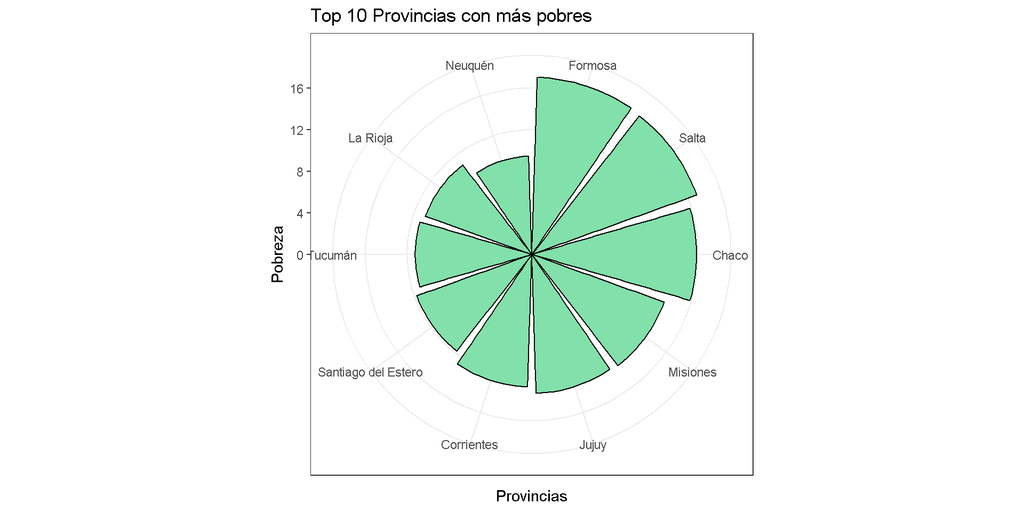

#### Top 10 provincias con mayor población:

Como último paso de esta visualización de los datos, procedemos a ver el Top 10 de provincias con mayor población:

```
##        province      pop
## 1  Buenos Aires 15625084
## 2       Córdoba  3308876
## 3      Santa Fe  3194537
## 4       Mendoza  1738929
## 5       Tucumán  1448188
## 6    Entre Ríos  1235994
## 7         Salta  1214441
## 8      Misiones  1101593
## 9         Chaco  1055259
## 10   Corrientes   992595
```

Claramente y por amplia mayoría, la provincia de Buenos Aires lidera el ranking con más de 15 millones de habitantes.

*Graficando nuevamente:*

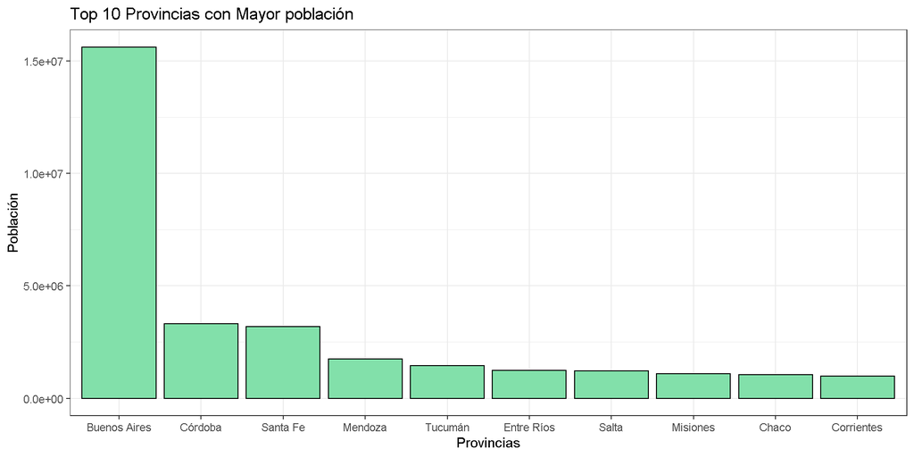

# Primeros pasos del modelo

### Mapa de Correlaciones

Comenzamos esta sección analizando las correlaciones entre las distintas variables para detectar su reciprocidad:

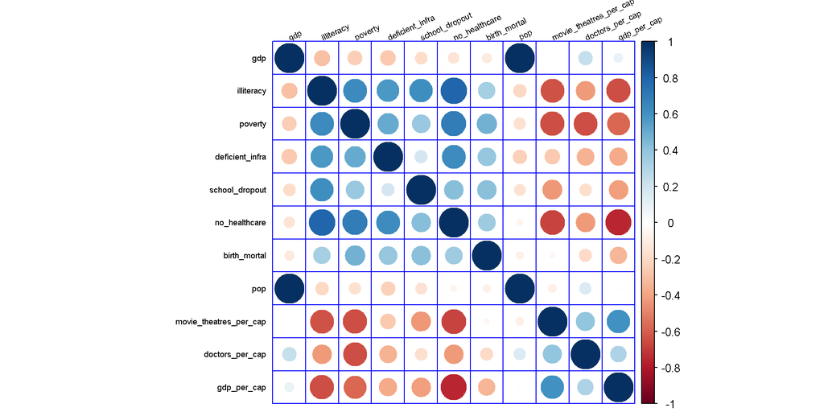

### Análisis de Componentes Principales (ACP)

Seguimos investigando la correlación entre variables, y para este caso aplicamos un análisis de componentes principales:

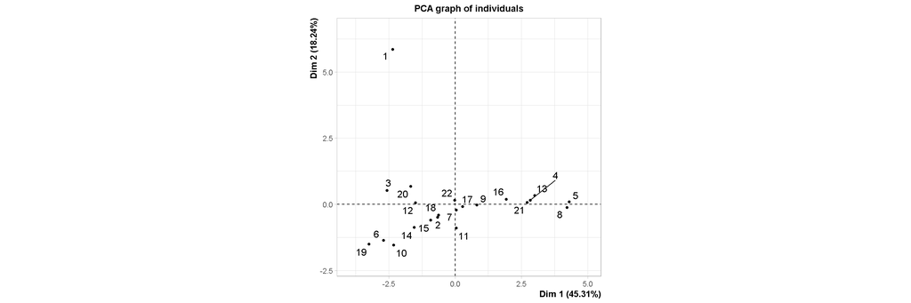

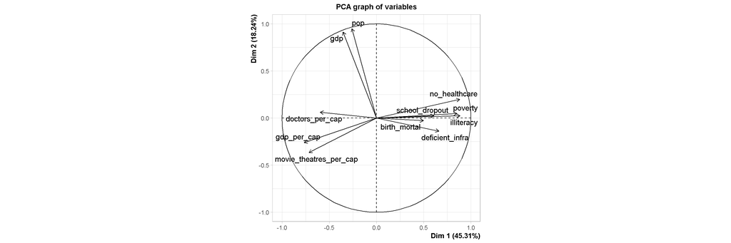

[output not shown]

```
##                               PC1         PC2         PC3         PC4
## gdp                    -0.1582148 -0.64562084  0.08575841  0.13064813
## illiteracy              0.3965746 -0.01680404  0.01966278 -0.19117745
## poverty                 0.3816128 -0.03337991 -0.11273291  0.22546167
## deficient_infra         0.2962042  0.09784329  0.07704802  0.44861477
## school_dropout          0.2718163 -0.01638785  0.40470794 -0.53099112
## no_healthcare           0.3954309 -0.14023352 -0.05579056  0.01962094
## birth_mortal            0.2229355  0.01868822  0.71715526  0.34326317
## pop                    -0.1159025 -0.67064119  0.06018650  0.13836607
## movie_theatres_per_cap -0.3202316  0.25785107  0.35404712  0.30442863
## doctors_per_cap        -0.2668417 -0.04399136  0.40384983 -0.39611218
## gdp_per_cap            -0.3423381  0.18368057 -0.01829020  0.15937724
##                                PC5          PC6         PC7         PC8
## gdp                     0.01757452 -0.166096613  0.01582623  0.01600738
## illiteracy             -0.15469050 -0.290664784  0.17491664 -0.63837385
## poverty                 0.28227664  0.186080779 -0.47111860 -0.02039417
## deficient_infra        -0.54266316 -0.423381376 -0.06112797  0.45001881
## school_dropout          0.31322816 -0.414012382  0.12727757  0.33927605
## no_healthcare          -0.30233226  0.066775356  0.04890494 -0.32504476
## birth_mortal            0.24990816  0.228614517 -0.14663771 -0.12962851
## pop                     0.02316588 -0.087011347  0.08027188 -0.03617117
## movie_theatres_per_cap -0.06394625  0.001522254  0.51249316 -0.18830863
## doctors_per_cap        -0.55156529  0.183102149 -0.47410412 -0.06318344
## gdp_per_cap             0.20193502 -0.636253540 -0.45771489 -0.33311142
##                                PC9        PC10         PC11
## gdp                     0.03399709  0.04881270 -0.708361664
## illiteracy              0.44721212 -0.23820874 -0.047292134
## poverty                 0.41542764  0.52927679 -0.018081014
## deficient_infra         0.10363729 -0.06113743  0.032109441
## school_dropout         -0.06406491  0.27177072  0.036299363
## no_healthcare          -0.68169834  0.38967687  0.001080511
## birth_mortal           -0.17094938 -0.36816529 -0.003878143
## pop                     0.09418518  0.03338664  0.698709055
## movie_theatres_per_cap  0.19453692  0.52220653 -0.013904297
## doctors_per_cap         0.14614673  0.13580545  0.023263560
## gdp_per_cap            -0.22228304  0.05909056  0.066079875
```

```
## Importance of components:
##                           PC1    PC2     PC3     PC4     PC5     PC6     PC7
## Standard deviation     2.2324 1.4166 1.02085 0.97466 0.86145 0.69656 0.57365
## Proportion of Variance 0.4531 0.1824 0.09474 0.08636 0.06746 0.04411 0.02992
## Cumulative Proportion  0.4531 0.6355 0.73023 0.81659 0.88405 0.92816 0.95808
##                            PC8     PC9    PC10    PC11
## Standard deviation     0.42962 0.38171 0.35987 0.03682
## Proportion of Variance 0.01678 0.01325 0.01177 0.00012
## Cumulative Proportion  0.97486 0.98810 0.99988 1.00000
```

Quizás esto último no resulte del todo agradable, pero paso a explicarlo de una forma muy sencilla. Básicamente, al realizar el análisis de componentes principales, obtenemos en total 11 componentes que pueden explicar la variabilidad de los datos que tenemos.

Como vemos en el cuadro de abajo, la sección de “Cumulative Proportion” nos dice que porcentaje de variabilidad de datos podemos explicar según la cantidad de componentes que utilizamos. Podemos ver que con un solo componentes llegamos a explicar nada más que el 45,31% de la variabilidad de los datos. A medida que vamos añadiendo más componentes vamos aumentando el porcentaje.

**Finalmente podemos ver todo esto resumido en el siguiente gráfico:**

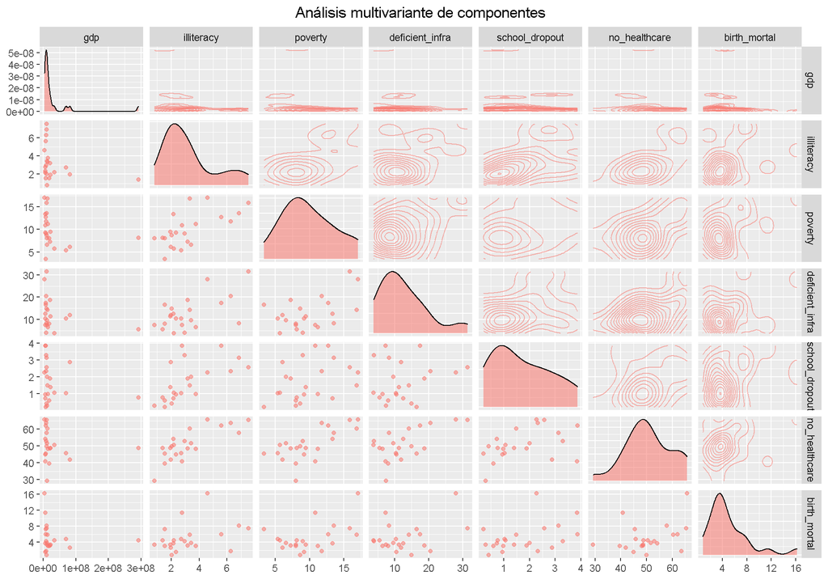

* * *

# Clusterización - Segmentación por Provincias

Comenzamos con el proceso de segmentación de provincias para ver como se agrupan, utilizaremos como herramienta el modelo de K-means, donde vamos a establecer 5 grupos distintos de clusters.

```
##   cluster        gdp illiteracy    poverty deficient_infra school_dropout
## 1       1 -0.3511209  1.3376140  1.2457868       1.0128833      0.7662390
## 2       2  4.2395054 -0.9950338 -0.4650914      -0.9928761     -0.8318866
## 3       3 -0.2542316 -0.3004243 -0.2573274      -0.3433315     -0.2721009
## 4       4 -0.2979586 -1.0438006 -0.9085420      -0.2803720     -1.1844261
## 5       5  0.3497268 -0.3984766 -0.6560188      -0.3844413      0.7455463
##   no_healthcare birth_mortal        pop movie_theatres_per_cap doctors_per_cap
## 1    1.28418465    0.7280511 -0.2251701             -0.8708274     -0.89011360
## 2   -0.21502324   -0.1676120  4.3290301             -0.2578908     -0.03817085
## 3   -0.08439651   -0.5423930 -0.2556950             -0.2127614      0.10413743
## 4   -1.38149639   -0.1390270 -0.4096526              1.8323841     -0.10902800
## 5   -0.86200897    0.3659745  0.1840678              0.6335183      1.58956654
```

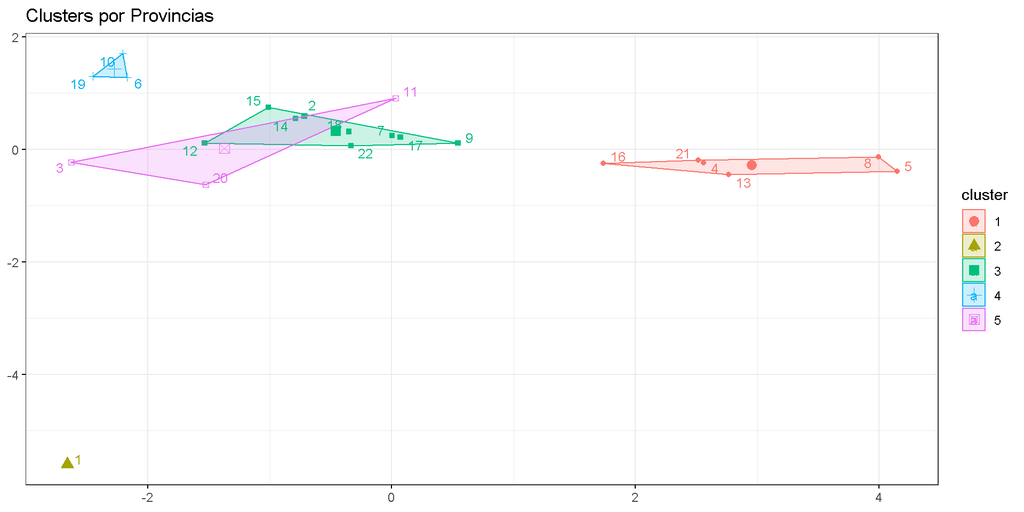

Una vez escaladas las variables, procedemos a generar los clusters como se muestran en la figura de arriba. Encontramos un total de 5 grupos diferentes como se había mencionado anteriormente.

Ahora procedemos a la clusterización de las variables más relevantes del modelo, agrupando a las provincias en base a sus similitudes o diferencias:

### Segmentación por PBI

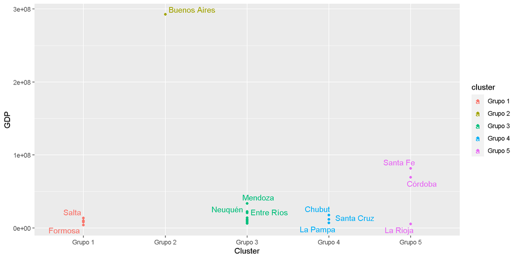

### 1. Segmentación por PBI per Cápita

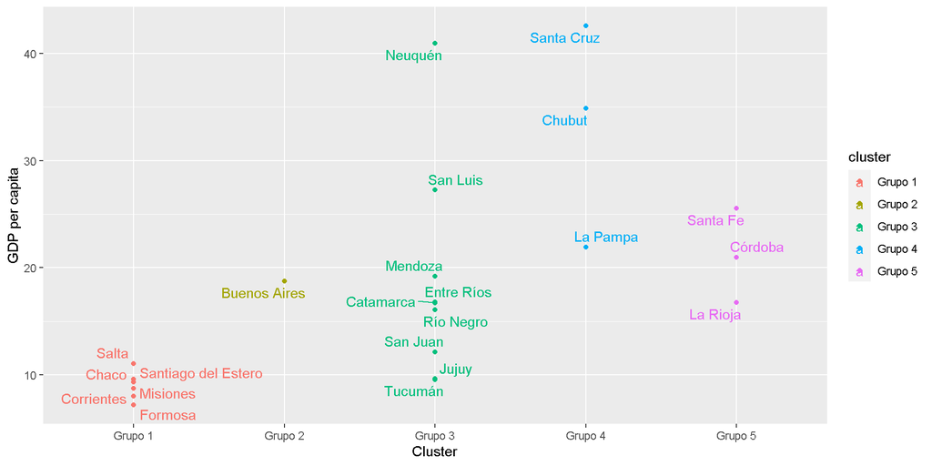

### 2. Segmentación por Pobreza

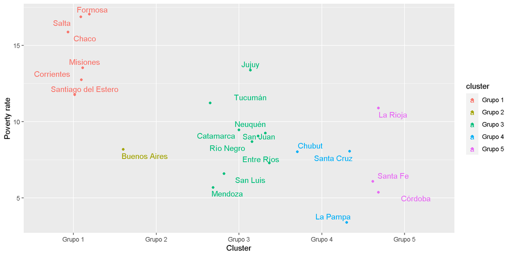

### 3. Segmentación por Inasistencia Sanitaria

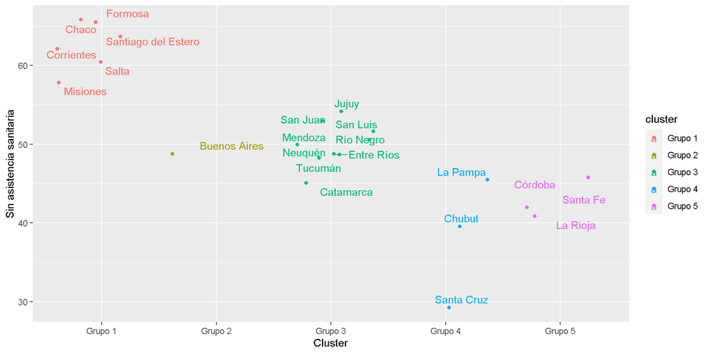

### 4. Segmentación por Infraestructura Deficiente

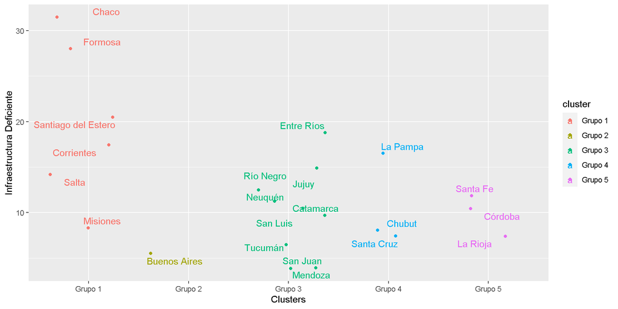

### 5. Segmentación por Analfabetismo

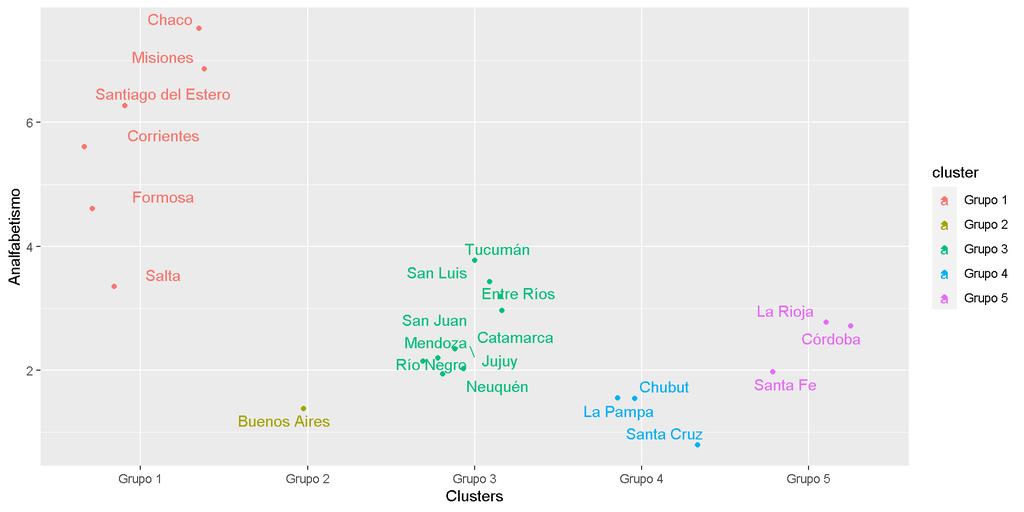

### 6. Segmentación por Abandono Escolar

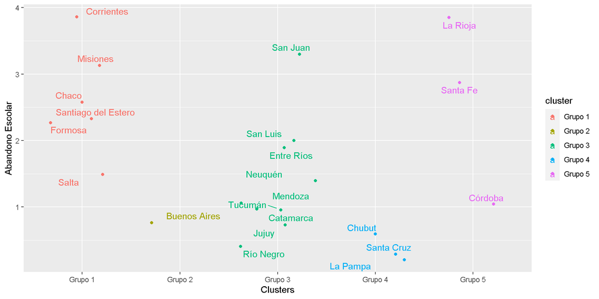

### 7. Segmentación por Doctores per Cápita

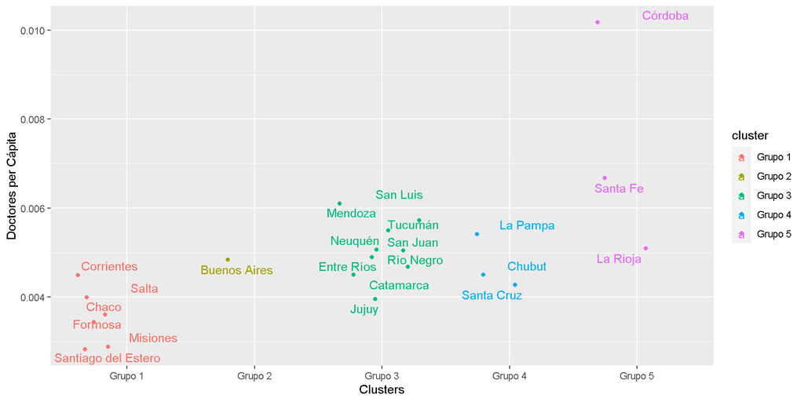

### 8. Segmentación por Mortalidad al Nacer

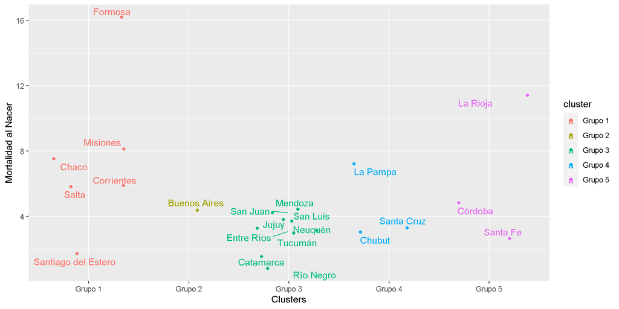

### 9. Segmentación por Cantidad de Cines

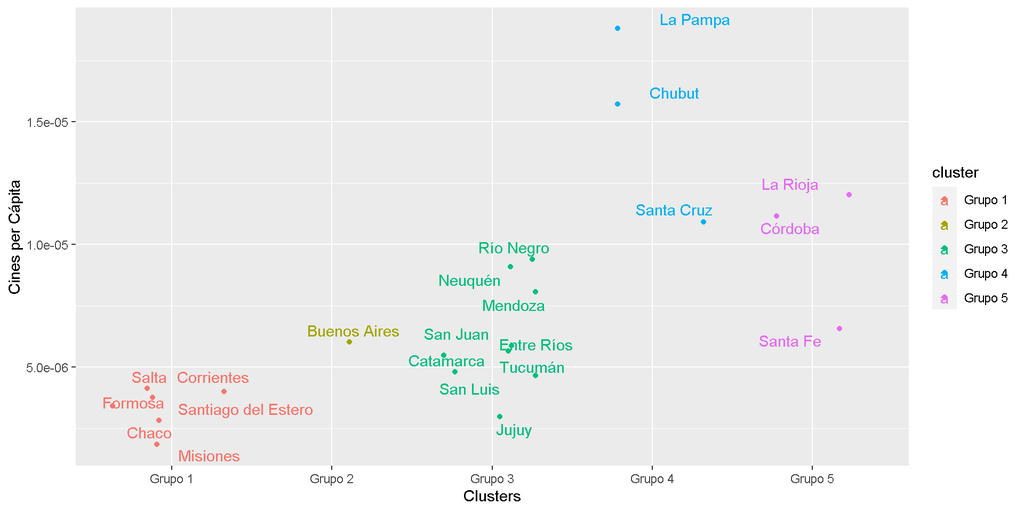

# Conclusiones

En base a los clusters determinados en la etapa anterior, vemos como se agrupan las distintas provincias. Observador claramente 5 grupos.

- 1er Grupo: Salta, Corrientes, Formosa, Santiago del estero, Chaco y Misiones.
- 2do Grupo: Buenos Aires.
- 3er Grupo: Río Negro, Neuquén, Mendoza, San Juan, Entre Ríos, Catamarca, Tucumán, San Luis y Jujuy.
- 4to Grupo: La Pampa, Chubut y Santa Cruz.
- 5to Grupo: La Rioja, Córdoba y Santa Fe.

Observamos un claro patrón en cuanto a algunas de las provincias que conforman el NEA (Grupo 1), y éste es la alta tasa de pobreza, analfabetismo y deserción escolar (entre otras) que ponderan en alto grado.

Luego se observa un patrón medio en cuanto al Grupo 3, el cual sería el que le sigue al Grupo 1. Luego el Grupo 2, Grupo 4 y Grupo 5 se encuentran por detrás.

No es el objetivo del informe el de decidir qué tipo de política aplicar. Pero si, en base al modelo previsto anteriormente, recomendar un cierto camino tentativo con el fin de enfocar los recursos hacia lugares donde la rentabilidad sea positiva. Por ejemplo, invertir un mayor porcentaje en educación y sanidad hacia los sectores más vulnerables del Norte Argentino, como así tambien a la región de Cuyo.

Tener el cuenta de que el modelo puede presentar cierto grado de error pero en lineas generales se trata de demostrar la composición de las variables económicas, políticas y sociales más importantes.

El qué hacer y cómo hacer queda en manos de las autoridades pertinentes. Sin embargo, esta pequeña aproximación intenta dar un marco general para actuar de manera eficiente y equitativa en lo posible en la aplicación de políticas públicas por el bien de la sociedad.